# 일자/시간대별 자전거 대여량을 예측: 회귀 모델!

## 0. sampleSubmission.csv을 열어서 예측해야 하는 것을 확인해 보자!

```python
import pandas as pd
submission=pd.read_csv("./data/sampleSubmission.csv")
submission
```

# 1. Data 불러오기 (train.csv)

## 1) 먼저, DataField 확인 이해

- **[년월일시 - datetime관련]**

**datetime** - hourly date + timestamp (년-월-일-시-분-초 형태)

- **[구분자(category)관련]**

**season** – 1 = spring, 2 = summer, 3 = fall, 4 = winter **==> 1-3월, 4-6월, 7-9월, 10-12월임. 즉 1사분기, 2사분기, 3사분기, 4사분기임**

**holiday** – whether the day is considered a holiday (공휴일이면 1, 아니면 0)

**workingday** - whether the day is neither a weekend nor holiday (근무일이면 1, 아니면 0)

- **[날씨, 기후 관련]**

**weather** (날씨)

1: Clear, Few clouds, Partly cloudy, Partly cloudy

2: Mist + Cloudy, Mist + Broken clouds, Mist + Few clouds, Mist

3: Light Snow, Light Rain + Thunderstorm + Scattered clouds, Light Rain + Scattered clouds

4: Heavy Rain + Ice Pallets + Thunderstorm + Mist, Snow + Fog

**temp** - temperature in Celsius (온도)

**atemp** - "feels like" temperature in Celsius (체감온도)

**humidity** - relative humidity (습도)

**windspeed** - wind speed (풍속)

- **[자전거 대여량]**

**casual** - number of non-registered user rentals initiated (비회원의 대여량)

**registered** - number of registered user rentals initiated (회원의 대여량)

**count** - number of total rentals (총 대여량)

## 2) 라이브러리 / 모듈 import

```python
import numpy as np
import pandas as pd

import matplotlib.pyplot as plt
import seaborn as sns
#%matplotlib inline

import warnings
warnings.filterwarnings('ignore')
```

# 3) Train 데이터 파일 읽어오기

```python
train=pd.read_csv('./data/train.csv')
```

```python
train.info()
```

- **datetime의 데이터타입(Dtype)이 object라는 것은 string(문자열)형태라는 의미**
- **년/월/일/시/분/초 형식의 수치형 데이터타입인 datetime64로 변환해두어야 분석이 용이함!**
- **pandas의 to_datetime() 함수 이용**

```python
train['datetime'] = pd.to_datetime(train['datetime'], format='%Y-%m-%d %H:%M:%S', errors='raise')
```

- https://docs.python.org/3/library/datetime.html#strftime-and-strptime-behavior

```python
train.info()
```

- **datetime의 데이터타입(Dtype)이 datetime64로 변환!**

```python
# 처음 5개의 데이터 셋(레코드) 확인
train.head()
```

**- windspeed에 0값만 확인되어 추가 확인이 필요!**

```python
#windspeed에 0이 아닌 값이 있는 지 추가 확인
train.head(20)
```

```python
train['windspeed']
```

**- windspeed가 0이 아닌 값도 확인됨. 그렇다면 실제 0이라기 보다는 데이터가 없는 경우를 0으로 넣었을 수 있음**

**- train.csv파일을 열어 전체적으로 확인해 보자!**

- **shape --> numpy.ndarray 객체의 method**

```python
train.shape
```

# 4) Test 데이터 파일 읽어오기

- **이번에는 read_cvs를 수행하면서 바로 datetime64 형태로 변환하여 읽어들이도록 함**
- **parse_dates 옵션**

```python
# pare_dates: 날짜 시간으로된 컬럼을 datetime64 형태로 변환
test = pd.read_csv('./data/test.csv',parse_dates=['datetime'])
```

```python
test.info()
```

**- datetime이 'datetime64'형태로 load됨을 확인!!**

```python
# (6493개 레코드(행),9개 feature(열) - casual, registered, count feature는 없음)
test.shape
```

```python
test.head()
```

# 2. 탐색적 데이터 분석(EDA) 시작

## 1) 중복값 확인

- **훈련 데이터, 테스트 데이터에 중복값이 있는지 확인**
- **.duplicated()**

```python
# train 셋의 중복값 확인
train.duplicated()
```

```python
# train 셋의 중복값의 총갯수 확인
train.duplicated().sum()
```

```python
# test 셋의 중복값 확인
test.duplicated()
```

```python
# test 셋의 중복값의 총갯수 확인
test.duplicated().sum()
```

## 2) 결측값 확인

**- 훈련 데이터, 테스트 데이터에 결측값이 있는지 확인**

**- .isnull()**

```python
# 각 feature별/레코들별로 True(결측값)/False로 표시해 줌
train.isnull()
```

```python
# train 셋에서 결측값의 전체 갯수를 feaure별로 확인
train.isnull().sum()
```

```python
#test 셋에서 결측값의 전체 갯수를 feaure별로 확인
test.isnull().sum() #결측값 없음
```

- **결측값 확인 다른방법 : missingno 라이브러리 - matrix()**
- **결측값의 위치에 흰색선을 표시함**

```python
!pip install missingno
```

```python
import missingno as msno
```

```python
msno.matrix(train, figsize=(12,5))
```

- 흰색선이 보이지 않으므로 결측값 없음
- **Titanic 데이터의 경우**

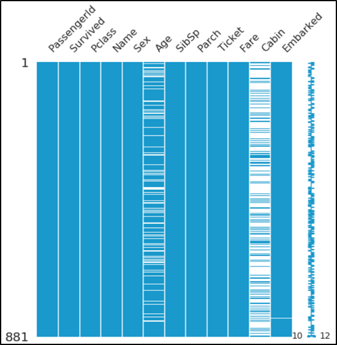

## 3) datetime feature의 분리

**- 년,월,일,시,분,초 데이터 추출 별도의 feature로 구성**

**- datetime64의 속성을 이용 (ex: dt.year, dt.month)**

**- dayofweek이라는 추가 feature 구성 - 요일 저장**

```python
# 1. 년도 추출
train['year']=train['datetime'].dt.year
```

```python
# 2. 월 추출
train['month']=train['datetime'].dt.month
```

```python
# 3. 일 추출
train['day']=train['datetime'].dt.day
```

```python
# 4. 시 추출
train['hour']=train['datetime'].dt.hour
```

```python
# 5. 분 추출
train['minute']=train['datetime'].dt.minute
```

```python
# 6. 초 추출
train['second']=train['datetime'].dt.second
```

```python
#7. 요일 추출  (월요일:0, 일요일:6)
train['dayofweek']=train['datetime'].dt.dayofweek
```

## 4) 7개의 feature가 추가되었음을 확인해 보자!

```python
train.shape
```

```python
train.head()
```

## 5) value_counts() 함수 - 요일별 데이터 수 counting

```python
train['dayofweek'].value_counts()
```

월,화,수,목,금,토,일 거의 비슷하게 분포되어 있음

## 7) test data의 datetime feature도 분리

```python
test['year']=test['datetime'].dt.year # 년도 추출
test['month']=test['datetime'].dt.month # 월도 추출
test['day']=test['datetime'].dt.day # 일 추출
test['hour']=test['datetime'].dt.hour # 시 추출
test['minute']=test['datetime'].dt.minute # 분 추출
test['second']=test['datetime'].dt.second # 초 추출
test['dayofweek']=test['datetime'].dt.dayofweek #요일 추출 , 월요일:0, 일요일:6
```

```python
test.shape
```

```python
test.head()
```

## 8) describe() 함수 - 기술통계분석

- **train set 기술통계분석**

```python
train.describe()
```

### (주의1) 명목(카테고리) 변수의 경우 평균값 등이 의미가 없음!

- **season, holiday, weather, year, month, day, hour, minute, second, dayofweek**

```python
# 분(minute)별 대여량의 데이터 분포 확인
train['minute'].value_counts()
```

```python
# 초(second)별 대여량의 데이터 분포 확인
train['second'].value_counts()
```

### (주의2) 분과 초는 단일값 (0)으로 구성, 머신러닝에 도움이 되지 않음

- **즉 feature로 사용하지 않음**
- **test set 기술통계분석**

```python
test.describe()
```

- train 셋: day (1~19)
- test 셋: day (20~31)

# 3. EDA - 시각화기반 분석

## 1) 먼저 datetime 변수와 자전거 대여량 간의 관계에 대해 확인해보자!

- **년도(year)는 자전거 대여량에 어떤 영향을 미칠 것인가?**
- **월(month)는 자전거 대여량에 어떤 영향을 미칠 것인가?**
- **일(day)는 자전거 대여량에 어떤 영향을 미칠 것인가?**
- **시간(hour)는 자전거 대여량에 어떤 영향을 미칠 것인가?**
- **(mimute, second은 분석에서 제외)**

```python
train.head(20)
```

- **각 feature의 count(자전거 대여량)의 평균값을 확인해야함 --> sns.barplot()**
- **그렇다면, 그 전에 년, 월, 일, 시 feature에 데이터가 골고루 분포되어 있는 지 부터 확인하자!**

```python
# 년도(year) 데이터의 분포 확인
train['year'].value_counts()
```

```python
# 월(month) 데이터의 분포 확인
train['month'].value_counts()
```

```python
# 일(day) 데이터의 분포 확인
train['day'].value_counts()
```

```python
# 시간(hour)별 대여량의 데이터 분포 확인
train['hour'].value_counts()
```

```python
# 년도와 자전거 대여량 평균값의 관계 확인
sns.barplot(x="year", y="count", data=train)
plt.show()
```

```python
sns.barplot(x=train['year'], y=train['count'])
plt.show()
```

```python
# 아래와 같이 해도 될까?  Day7_4 확인!
#sns.barplot(x=train.year, y=train.count)
plt.show()
```

- **year - 2011년보다 2012년의 대여량이 더 많음 (자전거 공유 서비스가 홍보가 되었기 때문으로 추측)**

```python
# 월과 자전거 대여량 평균값의 관계 확인

sns.barplot(x="month", y="count", data=train)
plt.show()
```

- **month - 날씨가 따듯한 때에 대여량이 많고,추울 때 대여량이 적음**
- **6월이 가장 많음. 7-10월도 많은편임. 1월의 자전거 대여량이 가장 적음**

```python
# 일과 자전거 대여량 평균값의 관계 확인

sns.barplot(x="day", y="count", data=train)
plt.show()
```

- **day - train 셋에는 1일부터 19일까지, test 셋에는 20일부터 31일까지 있음**
- **day는 count에 크게 영향을 미치지 않는 것으로 파악됨**
- **따라서, 이 데이터는 feature로 사용하지 않음!!**

```python
# 시간과 자전거 대여량 평균값의 관계 확인

sns.barplot(x="hour", y="count", data=train)
plt.show()
```

- **hour - 출퇴근 시간에 자전거 수요량이 상승함**
- **하지만 주말과 주중을 나누어 보면 어떨까? 이후, 확인필요!**

```python
# 추가. 월과 자전거 대여량 평균값의 관계를 년도별로 확인  hue='year'
sns.barplot(data=train, x='month', y='count', hue='year')
plt.show()
```

- **겨울보다는 여름 대여량이 많음**
- **2011과 2012의 월별 대여량 패턴은 유사함. 단 2012에 전반적으로 2011보다 대여량이 증가했음! (홍보효과? 대여사업번창?)**

```python
# 구분자 변수(season, workingday, holiday, dayofweek)들과 자전거 대여량 평균값의 관계 확인!
fig,((ax1,ax2),(ax3,ax4)) = plt.subplots(nrows=2, ncols=2, figsize=(16, 8))

sns.barplot(x="season", y="count", data=train, ax=ax1)
sns.barplot(x="workingday", y="count", data=train, ax=ax2)
sns.barplot(x="holiday", y="count", data=train, ax=ax3)
sns.barplot(x="dayofweek", y="count", data=train, ax=ax4)
plt.show()
```

```python
# 다음과 같이 ax로 표현하면 sns.barplot은 어떻게 되어야 하는가?
fig, ax = plt.subplots(nrows=2, ncols=2, figsize=(16, 8))

sns.barplot(x="season", y="count", data=train, ax=ax1)
sns.barplot(x="workingday", y="count", data=train, ax=ax2)
sns.barplot(x="holiday", y="count", data=train, ax=ax3)
sns.barplot(x="dayofweek", y="count", data=train, ax=ax4)
plt.show()
```

```python
# ax의 또다른 표현법1
fig,((ax1,ax2,ax3),(ax4,ax5,ax6)) = plt.subplots(nrows=2, ncols=3, figsize=(16, 8))

sns.barplot(x="season", y="count", data=train, ax=ax1)
sns.barplot(x="workingday", y="count", data=train, ax=ax2)
sns.barplot(x="workingday", y="count", data=train, ax=ax3)
sns.barplot(x="holiday", y="count", data=train, ax=ax4)
sns.barplot(x="dayofweek", y="count", data=train, ax=ax5)
sns.barplot(x="dayofweek", y="count", data=train, ax=ax6)
plt.show()
```

```python
# ax의 또다른 표현법2
fig, ax = plt.subplots(nrows=2, ncols=2, figsize=(16, 8))

sns.barplot(x="season", y="count", data=train, ax=ax[0][0])
sns.barplot(x="workingday", y="count", data=train, ax=ax[0][1])
sns.barplot(x="holiday", y="count", data=train, ax=ax[1][0])
sns.barplot(x="dayofweek", y="count", data=train, ax=ax[1][1])
plt.show()
```

```python
# 그외 날씨/기후 변수(weather, temp, humidity, windspeed)들과 자전거 대여량 평균값의 관계 확인!
fig,((ax1,ax2),(ax3,ax4)) = plt.subplots(nrows=2, ncols=2, figsize=(16, 8))

sns.barplot(x="weather", y="count", data=train, ax=ax1)
sns.pointplot(x="temp", y="count", data=train, ax=ax2)
sns.pointplot(x="humidity", y="count", data=train, ax=ax3)
sns.pointplot(x="windspeed", y="count", data=train, ax=ax4)
plt.show()
```

- **날씨가 나쁠수록 대여량이 준다**
- **날씨가 가장 안좋은 4의 경우 3보다 대여수량이 높아 보이지만 신뢰 구간이 낮은 것을 확인할 수 있다**

(참고) weather

1: Clear, Few clouds, Partly cloudy, Partly cloudy

2: Mist + Cloudy, Mist + Broken clouds, Mist + Few clouds, Mist

3: Light Snow, Light Rain + Thunderstorm + Scattered clouds, Light Rain + Scattered clouds

4: Heavy Rain + Ice Pallets + Thunderstorm + Mist, Snow + Fog

```python
train['weather'].value_counts()
```

## 2) 시간대별 대여량의 상세분석

- **(구분없이) 전체**
- **근무일 여부로 구분**
- **요일로 구분**
- **회원/비회원 여부로 구분**
- **날씨로 구분**
- **계절(분기)로 구분**

```python
# 시간과 자전거 대여량 평균값의 관계 (구분없이 전체) - pointplot()
sns.pointplot(x="hour", y="count", data=train)
plt.show()
```

```python
# 시간과 자전거 대여량 평균값의 관계를 "주중/주말(근무일 여부, workingday)"로 구분하여 확인
sns.pointplot(x="hour", y="count", data=train, hue="workingday")
plt.show()
```

- **working day - 주중(1)과 주말(0)로 나누어보면**
- **주중에는 출퇴근 시간에 대여랑이 많고 (registered(회원)의 패턴과 유사할까?)**
- **주말에는 낮시간에 대여량이 많음 (casual(비회원)의 패턴과 유사할까?)**

```python
# 시간과 자전거 대여량 평균값의 관계를 "요일(dayofweek)"로 구분하여 확인
sns.pointplot(x="hour", y="count", data=train, hue="dayofweek")
plt.show()
```

- **dayofweek - 요일로 나누어보면 주중/주말로 구분한 것과 유사한 패턴**
- **월(0)-금(4)은 출퇴근 시간에 대여량이 많고, 토(5),일(6)은 낮시간에 대여량이 많음**

```python
# 시간과 자전거 대여량 평균값의 관계를 "회원/비회원 여부(registered/casual)"로 구분하여 확인
# 질문! 왜 아래처럼 코딩하여야 할까? hue 구분자로 처리할 수 없는 것일까?

fig, axes =plt.subplots(1,1, figsize=(8, 5))
sns.pointplot(x='hour', y='casual', data=train, color="r")
sns.pointplot(x='hour', y='registered', data=train, color="b")
plt.show()
```

```python
# 시간과 자전거 대여량 평균값의 관계를 "날씨(weather)"로 구분하여 확인
sns.pointplot(x="hour", y="count", data=train, hue="weather")
plt.show()
```

- **weather - 날씨별로 보면 주중의 패턴과 유사함**
- **단, 날씨가 좋을 수록 대여량이 많고, 강한 비가 많이 올 때는 대여량의 거의 없음**

```python
# 시간과 자전거 대여량 평균값의 관계를 "계절(season)"로 구분하여 확인
sns.pointplot(x="hour", y="count", data=train, hue="season")
plt.show()
```

- **seoson - 3사분기(7-10월)에 대여량이 가장 많고, 1사분기(1-3월)에 대여량이 가장 적음**

## 3) 어떤 가설들이 가능할까?

- **datetime관련 변수들 중 year, month, hour은 자전거 대여량에 영향을 미칠 것이다. 하지만 day는 그렇지 않다.**
- **구분 변수들 중 workingday, dayofweek, season은 자전거 대여량에 영향을 미칠 것이다.**
- **날씨관련 변수 중 weather, temp는 자전거 대여량에 영향을 미칠 것이다.**
- **날씨관련 변수 중 humidity, windspeed는 추가 확인이 필요해 보임**

## 4) 월별 평균 온도 확인

```python
train.groupby('month')['temp'].mean()
```

'7,8,9'월 --> '10,11,12월' 순서로 기온이 높음!

## 5) Boxplot 비교 - 데이터 분포, 이상치 존재여부 등을 파악

- **시즌, 시간, 근무일 여부에 따른 자전거 대여량**

```python
fig, axes = plt.subplots(nrows=2, ncols=2, figsize=(20,10))

sns.boxplot(data=train, y="count",             ax=axes[0][0])
sns.boxplot(data=train, x="season", y="count", ax=axes[0][1])
sns.boxplot(data=train, x="hour", y="count", ax=axes[1][0])
sns.boxplot(data=train, x="workingday", y="count", ax=axes[1][1])

axes[0][0].set(ylabel='Count', title='# of Bike Sharing(Total)')
axes[0][1].set(xlabel='Seonson', ylabel='Count',title='# of Bike Sharing(Seonson)')
axes[1][0].set(xlabel='Hour of the Day', ylabel='Count',title='# of Bike Sharing(Hour of the Day)')
axes[1][1].set(xlabel='Working Day', ylabel='Count',title='# of Bike Sharing(Working Day)')
plt.show()
```

어떤 분석을 해 볼 수 있을까요?

- **(Seonson) - 3사분기(7~9월) 에 가장 수요가 많음**
- **(Hour of the Day) - 출퇴근 시간에 수요가 많고 극단치가 없음**
- **(Working day) - 근무일이 아닐 때(주말) 보다 근무일(주중)에 극단치(outlier) 데이터가 많은 편이다**

```python
#추가로 요일별로 대여량을 boxplotting해보고 싶다면...
sns.boxplot(data=train, x="dayofweek", y="count")
plt.show()
```

- **주중의 경우 (0,1,2,3,4) 아웃라이어가 많은 편**
- **상기의 workday 아웃라이어가 많은 편과 유사**

# 4. faeture간 상관관계 분석

## 1) 연속형 수치 데이터간 산점도

- **해당 feature는 날씨 관련 변수 중 기온, 풍속, 습도**

```python
fig,(ax1,ax2,ax3,ax4)=plt.subplots(ncols=4, figsize=(12,5))

sns.regplot(x="temp",y="count",data=train, ax=ax1)
sns.regplot(x="atemp",y="count",data=train, ax=ax2)
sns.regplot(x="windspeed",y="count",data=train, ax=ax3)
sns.regplot(x="humidity",y="count",data=train, ax=ax4)
plt.show()
```

- **temp -count와 양의 상관관계**
- **atemp -temp와 거의 유사한 패턴**
- **windspeed - 0인 데이터가 많음(관측치가 없기 때문인 것으로 추측)-> feature engineering에서 보정 후 판단 필요!**
- **humidity - 상관관계 잘 확인되지 않음. 0과 100인 데이터가 일부 존재함.**

## 2) correlation metrix로 확인

```python
corrmat = train.corr()
```

```python
corrmat
```

## 3) 히트맵으로 상관관계 확인

```python
plt.subplots(figsize=(20,10))
sns.heatmap(corrmat, annot=True)
plt.show()
```

## 양과 음의 상관관계가 섞여 있어 직관적으로 잘 파악이 안됨!

- **그렇다면, 모든 상관관계값을 절대값으로 변환하여 비교해 보자!**
  - **상관관계값을 절대값으로 취하고 단일색상(green)으로 표현해 주면 관계강도가 직관적으로 확인됨**

```python
plt.subplots(figsize=(20,10))
sns.heatmap(abs(corrmat), annot=True, cmap='Greens' )
plt.show()
```

## 4) mask를 써서 대각선 아래만 표현

```python
mask1 = np.triu(np.ones_like(corrmat)) # 대각선 포함 upper 삼각형--> 1
mask1
```

```python
plt.subplots(figsize=(20,10))
sns.heatmap(abs(corrmat), annot=True, cmap='Greens', mask=mask1)
plt.show()
# 이경우 대각선은 mask=True여서 표현 안됨
```

- numpy.tril_indices_from(array) : Return the indices for the lower-triangle of arr.

## 5) (절대값)상관관계 분석결과를 요약하면...

### feature와 count의 상관관계

- **날씨 관련 - weather(category), windspeed(0값 많음)는 count와 상관관계: 매우 낮음 <=0.1**
- **날씨 관련 - temp, atemp, humidity와 count의 상관관계:0.3~0.4**
- **datetime 관련 - hour와 count의 상관관계:0.4, year와 count의 상관관계:0.26**
- **구분자 관련 - season, workingday, holiday, dayofweek과 count의 상관관계: 매우 낮음 <=0.16 --> 왜 그럴까?**
- **count와 가장 상관관계가 높은 것은 registered, casual 이지만 이 변수들은 사용할 수 없음(테스트 데이터에도 없음)**

### feature간 상관관계

- **temp와 atemp: 상관관계 매우 높음(0.98)--> 다중공선성 문제!-> 둘다 동시에 feature로 사용하기에는 적합하지 않음**
- **month와 season - 유사 구분자 이니까 상관관계 높을 수 밖에 없음**

## 6) 다중공선성 문제 (multicollinearity problem)

- 회귀분석에서 독립변수들 간에 강한 상관관계가 나타나는 문제로 적절한 회귀분석을 위해 해결해야 함
- 1) 하나의 변수로 치환
- 2) 상관관계가 높은 독립변수 중 하나 혹은 일부를 제거
- **drop( 컬럼명, axis=1(컬럼삭제일때), inplace=True(삭제후 원본데이터에 덮어쓸때)**

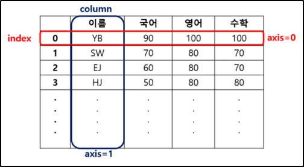

- **1. 차원축소: temp와 atemp (2차원)를 하나의 변수 (1차원)로 변경함**
- 주성분 분석(Principal component analysis; PCA)
- 고차원의 데이터를 저차원의 데이터로 환원시키는 기법
- 직교 변환을 사용하여 서로 연관 가능성이 있는 고차원 공간의 표본들을 선형 연관성이 없는 저차원 공간(주성분)의 표본으로 변환

```python
from sklearn.decomposition import PCA
pca= PCA(n_components=1, random_state=123)  # random_state: seed값
```

```python
train_temp = pca.fit_transform(train[['temp', 'atemp']])
test_temp = pca.transform(test[['temp', 'atemp']])
```

- **차원을 축소를 통해 새로 생성된 trian_temp와 test_temp를 각 데이터셋에 temp_pca 라는 이름으로 추가**

```python
train['temp_pca']= train_temp
test['temp_pca']= test_temp
```

- **2. atemp 제거**

```python
train.drop(['atemp'], axis=1, inplace=True)
```

```python
train.head()
```

```python
test.drop(['atemp'], axis=1, inplace=True)
```

```python
test.head()
```

## 7) 종속변수인 count 에 대한 각 feature의 상관관계를 내림차순으로 정렬

```python
corrmat = train.corr()
```

```python
corr_df=pd.DataFrame(corrmat['count'])
corr_df
```

```python
corr_df['count'].sort_values()
```

```python
corr_df['count'].sort_values(ascending=False)
```

- **상관관계값을 절대값으로 비교**

```python
abs(corr_df['count']).sort_values(ascending=False)
```

- **(registered, casual)은 제외하고 보자면...**
- **hour, temp, humidity, year 순으로 count와 상관관계가 높음**
- **날씨 관련 - temp, humidity와 count의 상관관계:0.3~0.4**
- **datetime 관련 - hour, year, month, season순 (day는 제외)**
- **특히, hour와 count의 상관관계:0.4**

### [추가 학습]

- 다음 소스 코드를 이용하여 season이 3,4 인 경우의 hour, count, season만 뽑아내어 train_temp라는 DF에 저장해 봅시다.
- lemonade.loc[lemonade['Revenue']>45, ['Date','Revenue']]

```python
train_temp=train.loc[ train['season']>=3, ['hour', 'count','season']]
train_temp
```

- train_temp의 hour과 count를 이용하여 barplot을 그려봅시다.

```python
sns.barplot(x="hour", y="count", data=train_temp)
```

# count (대여량) 값의 데이터 분포도 파악

## count값의 로그 변환 전

```python
ytrain=train["count"]  #trainWithoutOutliers  -> train
sns.histplot(ytrain)
plt.show()
```

## count값의 로그 변환 후

```python
ytrain_log = np.log1p(ytrain)
```

```python
sns.histplot(ytrain_log)
plt.show()
```

- **원래보다는 왜곡정도가 완화됨**

## [참고] 로그를 취하여 분포를 변환시키는 이유

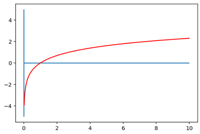

- 0<x<1 --> (-무한대<y<0)으로 기울기가 가파름
- 따라서 0에 가깝게 모여있는 x값들에 로그를 취하면 y값은 매우 큰 범위로 벌어짐
- 반면 x>1 --> y값이 크게 차이나지 않음
- 즉, 1 이상의 넓은 범위의 x는 로그를 취하면 비교적 작은 구간내의 y값으로 변환됨
- 결국, 밀집되어 있는 데이터는 퍼지게, 퍼진 데이터는 밀집되게 하는 효과
- 따라서 한쪽으로 몰려있는 데이터에 로그를 취하면 넓게 퍼지게 함으로써 분포의 왜곡을 완화하는 효과가 발생함